# Databehandling (R-skript) og rapport (Quarto) - Solubilisering

Author

NSA og JK

# 1. Opsætning af Rstudio

Opret en mappe på din computer (fx FA511_Lab1).

Download excel filer ”Data” og ”Kontrol” fra Its-Learning og gem filerne i din mappe.

Åbn excel filer og gem dem i ”csv” format (”csv” stands for ”comma-separated values”; den er fordelagtigt at tal og kolonner er entydigt defineret). Opret et nyt R-projekt i din mappe.

Lav en ny R-skript og gem den (File – Save as – Giv det et navn).

# 2. Importer datasæst

Load “Tidyverse” og “here”:

**Click here for code**

```r
library(tidyverse)
library(here)
```

Importer datasæt “Data.csv” og “Kontrol.csv” og giv dem et navn (jeg har brugt ”data” og ”kontrol” og brug kommando ”read_csv2”. Kommando ”here” angiver filvejen, men den virker kun hvis filen er i den samme mappe! Du kan tjekke hvilken filveje der bruges (bliver vist i konsolen nedenunder) nor du loader den.

**Click here for code**

```r
data <- read_csv2(here("Data.csv"))
kontrol <- read_csv2(here("Kontrol.csv"))
```

# 3. Databehandling for ibuprofen

Der laves en ny tabel fra ”data” som kun indeholder data for ibuprofen. Giv den et navn (jeg har brugt ”ibu” og ”ibu_kontrol”):

**Click here for code**

```r
ibu <- select(data,Opløsningsmiddel,Solubiliseringsmiddel,Koncentration,Ibu1,Ibu2,Ibu3)
ibu_kontrol <- select(kontrol,Ibu1,Ibu2,Ibu3)
```

Der beregnes middelværdi (mean) og standardafvigelse (sd) for ”ibu”. Her bruger vi ”mutate” kommando, hvor der angives at vi vil lave beregner i rækker. ”%>%” betyder at der skal bruges kommandoer efter hinanden (bare en måde at skrive kortere kode).

**Click here for code**

```r
ibu <- ibu %>%
  rowwise (Koncentration) %>%
  mutate(mean(c_across(Ibu1:Ibu3))) %>%
  mutate(sd(c_across(Ibu1:Ibu3))) %>%
  rename(mean="mean(c_across(Ibu1:Ibu3))",
         sd="sd(c_across(Ibu1:Ibu3))")
```

Til sidst beregnes der middelværdi og standardafvigelse for kontrollen (den ækvilibreret prøve). Vi sætter først alle værdier i en kolonne (“pivot_longer”): og beregner derefter værdier med ”sd(ibu_kontrol$value” og runder værdier til 2 decimaler. Det kan være nødvendigt at tilpasse antal decimaler for de andre API i round kommando.

**Click here for code**

```r
ibu_kontrol <- pivot_longer(
  data=ibu_kontrol,
  cols=1:3
)
```

Derfter beregnes mean (og sd) ”mean(ibu_kontrol$value” og runder værdier til 2 decimaler. Det kan være nødvendigt at tilpasse antal decimaler for de andre API i round kommando.

**Click here for code**

```r
ibu_kontrol_mean<-mean(ibu_kontrol$value)
ibu_kontrol_mean<-round(ibu_kontrol_mean, digits=2)

ibu_kontrol_sd<-sd(ibu_kontrol$value)
ibu_kontrol_sd<-round(ibu_kontrol_sd, digits=2)
```

Værdier vil blive vist i “Global Environment” til højre. Det giver ikke ret mening her med tabel eller figur og disse værdier angives bedst direkte i teksten.

Der plottes data for “ibu” i ggplot. Det er en længere stykke kode… (se kommentarer i selve koden). Jeg anbefaler at eksportere grafen som billedet, så I ikke bruger kode for at vise grafen i selve rapporten (skal være i resultatafsnit). Alternativt kunne man bruge her “print” kommando.

**Click here for code**

```r
Graf_ibu <- ggplot(
  # Grafen laves som objekt, så den ikke blive vist med de samme med koden i Quarto.
  # I kan vise grafen med "print" eller eksportere den som billede for at sætte den ind i Quarto.
  data = ibu,
  mapping = aes(
    x = factor(Koncentration),
    # x-aksen sættes som "faktor", så søjler bliver vist uafhængig af tal på x-aksen
    y = mean,
    fill = Opløsningsmiddel
  )
)+
  geom_col(
    position = "dodge"
    # Det betyder at søjler kommer på siden af hinanden
  )+
  geom_errorbar(
    mapping = aes(
      x = factor(Koncentration),
      ymin = mean-sd,
      ymax = mean+sd,
      group = Opløsningsmiddel,
      width = (0.3)
    ),
    position = position_dodge(0.9)
    # Obs: Det kan være at man skal tilpasse (sammen med width)
    # Fejllinjer skal sidde i midten af kollonen
  )+
  facet_grid(
    .~Solubiliseringsmiddel,
    scales = "free_x"
    # Det betyder at man få alle 3 grafer i en figur
  )+
  labs(
    x = "Koncentration solubiliseringsmiddel (%)",
    y = "Ibuprofen (mg/ml)",
  )+
  theme_classic(
  ) +
  theme(
    legend.position =c(0.12,0.88)
    # Her kan der tilpasses hvor legenden skal vises
    # Det kan være nødvendigt at tilpasse værdier
  )
```

# 4. Databehandling for paracetamol og sulfadiazin

Du kan nu kopiere hele koden for ibuprofen og tilpasse den til de andre 2 API, dvs. “para” og “sulfa” i sted af “ibu” i hele koden.

Prøv selv at tilpasse koden.

# 5. Opsætning af rapporten i Quarto

Der kan opsættes et ny Quarto dokument, men der anbefales at bruge template, som findes på Its-Learning, så dokumentindstillinger er korrekte.

Giv dokumentet en titel og indsæt jeres navn (I skal skrive en fælles rapport med jeres medstuderende, som I har udført forsøget sammen).

Rapporten skal have 4 afsnit:

1. Introduktion
2. Databehandling
3. Resultater
4. Diskussion

Brug # for at sætte en titel og ## for en untertitel.

# 5.1. Introduktion

Skriv en kort og præcis introduktion til forsøget. Det følgende skulle indgå i introduktionen:

*Solubilisering*: Hvorfor vigtigt i lægemiddelformulering? Introducer kort solubiliseringsmidler, som blev brugt i forsøget. Man kan gerne vise strukturer af hjælpestoffer i en samlet figur. I kan tegne strukturer selv eller kopiere den fx fra wikipedia (men tjek at strukturen er rigtigt).

*Målsætning*: Beskriv kort målsætning af eksperimenter.

*API*: Introducer kort API, som blev undersøgt. Gerne vis deres strukturer. Vigtigt i sammenhæng med forsøget er stoffernes fysisk-kemiske egenskaber (syre/base, logP, opløselighed).

For at tilføje et billede:

[figure not shown]

# 5.2. Databehandling

Her vises koder, som blev brugt til dataanalyse. I kan gerne skrive korte kommentarer og laver underafsnit for hvert API.

# 5.3. Resultater

Giv en kort beskrivelse og interpretation af resultater og vis resultater i figurer (indsæt koden her). I kan gerne lave et afsnit for hvert API. Husk at angive resultater for de ækvilibrerede prøver. Dette kan bedst skrives direkte i tekst, fx “Koncentration af (API) i den ækvilibreret prøve blev bestemt til xx ± xx mg/ml.”

Generelt skal afnsit i en rapport IKKE starte med en figur eller tabel. Altid start med at skrive en kort tekst.

Figuren kan sættes ind direkte i Quarto (hvis I har gemt den som billede):

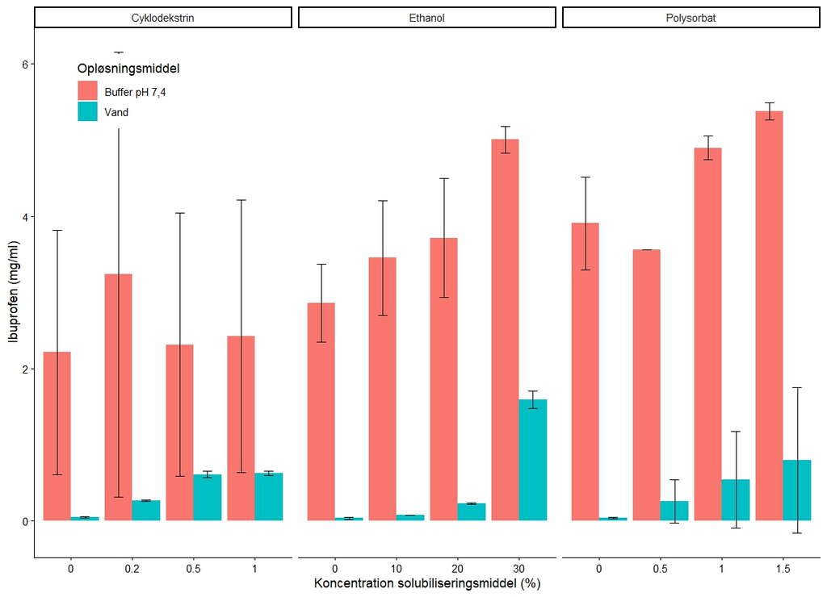

Figur 1: Effekt af solubiliseringsmiddel på opløseligheden af ibuprofen i vand og i buffer.

Alternativt kan I bruge “print” kommando:

**Click here for code**

[figure not shown]

```r
print(Graf_ibu)
```

Husk at skrive en figurtekst.

# 5.4. Diskussion

Skriv en kort og præcis diskussion om resultater og tag hensyn til de fysisk-kemiske egenskaber af API’er. Passer resultater til jeres forventninger? I kan også skrive en kort (og meningful) fejldiskussion.